# Agua

Osvaldo

3/4/2020

# Regresión lineal sobre el suministro de agua potable

## Pruebas para el modelo

### Verificación de relación lineal

Para ello haremos uso de gráficas y de una matriz de correlaciones:

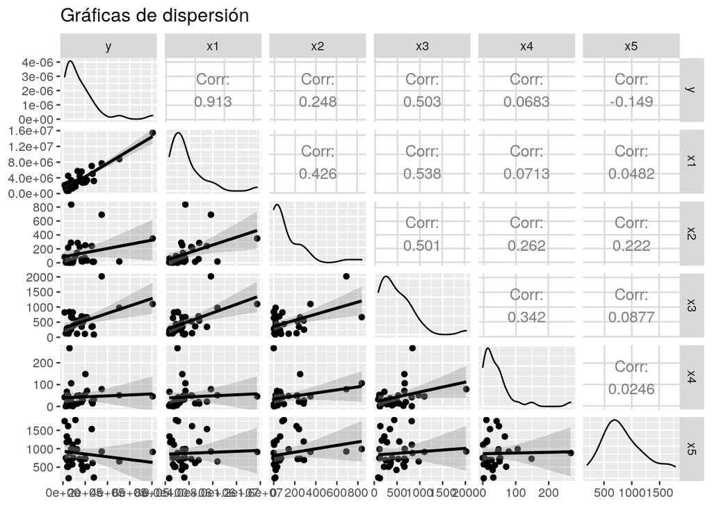

Lo que se aprecia en el modelo es que *x1* y *y* tienen una alta correlación y su gráfico casi forma una linea recta; mientras que con las demás es difícil establecer una relación directa, por que podríamos decir que *x3* tiene una alta correlación con *y* pero no parece suficiente como para afirmar tal cosa. Si bien no podemos descartar el modelo aun, podemos darnos cuenta de que algunas variables no nos van a servir, no podemos asegurarlos hasta que realicemos el *método de selección de variables*; esto en dado caso de que el modelo si ajuste a los datos, lo cual sabremos al obtener el modelo y ver si es significante y ademas que cuente con un R2 alto que nos convenza de seguir.

### Obtención del modelo

```
##
## Call:
## lm(formula = y ~ ., data = Datos_1)
##
## Residuals:
##     Min      1Q  Median      3Q     Max
## -122330  -32405    5644   29438  103902
##
## Coefficients:
##               Estimate Std. Error t value Pr(>|t|)
## (Intercept)  3.060e+04  2.905e+04   1.053   0.3019
## x1           5.096e-02  4.325e-03  11.783 6.28e-12 ***
## x2          -1.363e+02  6.560e+01  -2.077   0.0478 *
## x3           3.545e+01  3.546e+01   1.000   0.3266
## x4           5.799e+01  2.183e+02   0.266   0.7926
## x5          -6.556e+01  2.638e+01  -2.486   0.0197 *
## ---
## Signif. codes:  0 '***' 0.001 '**' 0.01 '*' 0.05 '.' 0.1 ' ' 1
##
## Residual standard error: 58350 on 26 degrees of freedom
## Multiple R-squared:  0.8905, Adjusted R-squared:  0.8695
## F-statistic:  42.3 on 5 and 26 DF,  p-value: 1.117e-11
```

Vemos de manera un tanto sorprendente que a pesar de lo visto en las gráficas anteriores el modelo es significante para un *alpha=0.05* y no solo eso sino que la R2 ajustada tiene un valor muy alto por lo que este modelo describe en un 87% la variabilidad de *y*, lo cual es sorpresivo despues de ver las gráficas. Aunque algo que nos deja con cierta inquietud es que haya un error estandar residual tan grande, pero bien dado que el resto de los atributos del modelo son muy buenos parece que podemos continuar.

### Metodo de selección de variables

Para esto utilizaremos el criterio de selección de Akaike(AIC), que mide tanto la bondad de ajuste del modelo como la complejidad de este, con lo que nos puede dar una muy buena respuesta en si es correcto retirar o no alguna variable y también para el caso de incluir o no una variable, ya que es una medición que toma en cuenta que tanto mejora el modelo con una variable mas pero también penaliza si lo vuelve mas complejo y no lo mejora tanto.

El modelo que arroje un menor estadístico *AIC* sera el elegido.

```
##
## Call:
## lm(formula = y ~ x1 + x2 + x5, data = Datos_1)
##
## Residuals:
##     Min      1Q  Median      3Q     Max
## -118155  -33191    9096   36696  104672
##
## Coefficients:
##               Estimate Std. Error t value Pr(>|t|)
## (Intercept)  4.090e+04  2.698e+04   1.516   0.1408
## x1           5.276e-02  3.832e-03  13.767 5.46e-14 ***
## x2          -1.080e+02  6.004e+01  -1.799   0.0829 .
## x5          -6.603e+01  2.605e+01  -2.535   0.0171 *
## ---
## Signif. codes:  0 '***' 0.001 '**' 0.01 '*' 0.05 '.' 0.1 ' ' 1
##
## Residual standard error: 57670 on 28 degrees of freedom
## Multiple R-squared:  0.8848, Adjusted R-squared:  0.8725
## F-statistic: 71.71 on 3 and 28 DF,  p-value: 2.953e-13
```

Como se puede apreciar, el modelo mejora un poco al deshacerse de las variables que no aportaban nada lo cual no era algo esperado ya que al ejecutar un método de este tipo se espera mas un modelo un poco peor pero mucho menos complejo.

Al hacer esto nos quedamos únicamente con *x1*, *x2* y *x5* que son: la población con agua potable, los mantos superficiales de donde se extrae el agua y la precipitación pluvial. Lo cual para nuestro propósito sirve de buena manera ya que tenemos los datos de la población y la precipitación pluvial a fácil alcance y la cantidad de mantos es algo relativamente fácil de medir. Otra ventaja de este nuevo modelo es que vemos que no necesitaremos la cantidad de mantos subterráneos ni la cantidad de plantas potabilizadoras con lo cual podemos ahorrarnos una buena parte del trabajo.